# Big Data Cup

Quinn MacLean

4/10/2022

## Introduction

Currently, there is a lot of advanced analytics focusing on [shot quality, defending shots/goals](https://drive4five.blog/2021/01/06/hockey-advanced-statistics-stats-nhl-sports-analytics-aidan-resnick/) and play during even strength. During the Tracking Data Panel at the 2022 Ottawa Hockey Analytics (OTTHAC), measuring defensive performance was posed as the current area of tracking analytics that had the biggest opportunity and the most difficult to solve. Shawn Ferris echoed this sentiment in a 2020 hockey-graphs where he said [there is still much more to learn about shorthanded defense with respect to understanding optimal in-zone formations and evaluating individual players](https://hockey-graphs.com/2020/04/16/using-data-to-inform-shorthanded-neutral-zone-decisions/#more-24218). This paper aims to model around successful defensive plays as a way to scout and identify defensive performance during penalty plays.

A successful defensive play is based on the following event:

**Successful Defensive Plays**:

- Takeaway
- Unsuccessful Pass
- Dump In/Out resulting in change of possession
- Failed Shot attempt
- Unsuccessful Zone Entry
- Puck Recovery resulting in change of possession

Current event metrics assign defensive play credit for takeaways, puck recoveries and blocked shots but these events don’t account for a majority of events such as passing, zone entry and dump in/out plays. To do so, we rely on tracking movement data to identify the closest opposing player to an offensive player as a way to give credit to a defender for the outcome of the play. The assumption we are using is that the closest defender or the one most prominent in the frame is the one most likely to be contributing to the outcome of a play. Each offensive player is assigned a closest defensive player so it is possible for a defender to be guarding multiple players for a given event. We did not identify the opposing player closest to the location of the actual play given our assumption that the defender guarding the offensive player is again most likely to contribute to the outcome of the play. By merging the event data to the approximate time frame of the tracking data, we can gain valuable insight into the average location and separation at start, leading up to, during the event, and after the event. Additionally, these separation metrics also allows us to identify the closest defenders.

## Modelling Approach

Using a similar approach to [Jonathan Judge from Baseball Prospectus](https://www.baseballprospectus.com/news/article/38289/bayesian-bagging-generate-uncertainty-intervals-catcher-framing-story/), a generalized linear mixed effects model using Monte Carlo Markov Chains (MCMC) was created to identify, which defensive player (based on closest defensive player assignment to each offensive player) had the greatest effect in adjusting the outcome of a defensive play. Our MCMC uses 5 chains and 10,000 iterations per chain to simulate and get an effective total sample size. In the mixed effects model, we fit the closest defensive player as the random effect modeling for the assumption that a defensive player can alter the result of a play, especially for penalty killing situations where a defensive play is even more important to the end result of the game. Through our exploratory analysis, we found that the following fixed variables were identified as determining a successful defensive play:

- **Separation**: Avg. Offensive player separation or distance to any player on the ice during an event
- **Net Separation**: Avg. Offensive player separation to the net during an event
- **Closest Opposition Player Separation**: Avg. Offensive player separation to opposition team during an event
- **Closest Teammate Player Separation**: Avg. Offensive player separation to offensive team during an event
- **Absolute x-Distance to Passer/Shooter**: Avg. distance of an offensive player to the passer or shooter
- **Absolute x-Distance to Event Recipient**: Avg. distance of an offensive player to the recipient of the event

All separation and distance variables were centered and scaled to ensure a consistent relative effect of variables in the model.

### Model Results & Evaluation

Defended Play Success Model Summary

Method: Bayesian MCMC GLM Mixed Effects Model | Chains: 5 | 10,000 Iterations

| Coefficient | Estimates | Std Error | CI Low (5%) | CI High (95%) |
| --- | --- | --- | --- | --- |
| Intercept | -0.51 | 0.099 | -0.70 | -0.31 |
| Separation | -0.18 | 0.048 | -0.28 | -0.09 |
| Net Separation | -0.08 | 0.041 | -0.16 | 0.00 |
| Closest Opposition Player Separation | 0.08 | 0.044 | -0.01 | 0.16 |
| Closest Teammate Player Separation | -0.08 | 0.041 | -0.16 | 0.00 |
| Absolute x-Distance to Passer/Shooter | -0.14 | 0.043 | -0.23 | -0.06 |
| Absolute x-Distance to Event Recipient | 0.11 | 0.048 | 0.01 | 0.20 |
| τ00 defender_id | 0.78 | 0.190 | 0.47 | 1.18 |

Data for model was centered & scaled

The following charts help to evaluate how effective our model was at fitting. The first check (on left) is on how well the posterior does in its predictions. This chart will show how *Yrep* (expected defended plays in the replicated simulations) compares to *Y* (actual defended play results). We can see that the model observed the binomial distribution of the output (successfully defended play or not) fairly well, which leads us to believe there are sufficient modeling results.

The second check is to evaluate whether the distribution has reached a convergence towards the target distribution (can be more difficult with MLE models). The second chart (on right) helps to show that variables of the model had proper convergence. We used [Gelman and Rubin’s scale reduction factor](https://mc-stan.org/docs/2_18/reference-manual/notation-for-samples-chains-and-draws.html) or *Rhat*, which helps to show variance within the chains. Typically, you’d want a number near 1 and less than 1.05. The distribution of all variables and intercepts (defensive players) below seem to show a proper convergence of variables within the model. Given there is evidence of proper variance among defenders and the variables had properly converged, we can conclude that this Bayesian model can be helpful to use to evaluate defensive play during power plays.

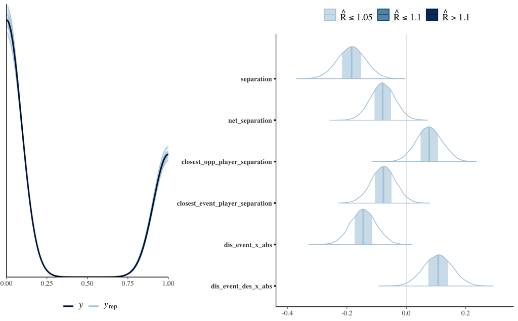

In determining player performance relative to average, we created a “without defender” metrics, which show the probabilistic outcome of the play not accounting for a specific defender’s involvement. The average difference between the MCMC mean and “without defender” metric helps to create our **Defending Plays Above Average (DPAA)** metric. *DPAA* shows the lift in probability a defensive player has on the outcome of a play. Any play with a *DPAA* greater than 0 can be defined as a positively defended play.

As a result, the model tends to identify Dump In/Outs as the event that has the highest probability of a positively defended event (e.g. Dump In/Outs resulting in a turnover). Takeaways and Puck Recoveries tend to be less positively defended which may be due to a secondary defender’s ability to disrupt a play. Passes are one of the most difficult plays to defend given there is a higher probability of a pass being completed successfully than disrupted by a defender. Given this information, we can also use the *DPAA* metric specific for passing plays as a way to identify those defenders who were especially effective in disrupting offensive movement during a power play. Shawn Ferris said that “We know that deploying better offensive players, [controlling more entries, and passing after those entries all lead to more shorthanded goals over time](https://hockey-graphs.com/2020/04/16/using-data-to-inform-shorthanded-neutral-zone-decisions/#more-24218).” Players with a reputation of defending the zone line (“blue line”) and disrupting passing are more likely to be on the ice during shorthanded defensive play.

DPAA Avg by Event

DPAA: Defended Plays Above Average | Positively Defended Plays are DPAA > 0

| Event | Event Count | DPAA | Positive Defended Plays | Positive Defended Plays % |
| --- | --- | --- | --- | --- |
| Dump In/Out | 46 | 0.161 | 41 | 89% |
| Puck Recovery | 138 | 0.047 | 73 | 53% |
| Zone Entry | 26 | 0.022 | 18 | 69% |
| Shot | 29 | 0.014 | 19 | 66% |
| Takeaway | 10 | 0.004 | 5 | 50% |
| Play | 258 | -0.033 | 158 | 61% |

Play is a Passs

## Tournament Performance Analysis

Using our model, we can evaluate the team performance during power plays as well as identify top and bottom individual performers as a way for teams to build a “penalty killer” shift.

### Team Performance

USA, Finland, and Russian Olympic Committee (ROC) were able to have a average DPAA rating greater than 0, largely due to their ability to defend passes. USA is interesting case study given their low amount of passes seen but saw the highest amount of Dump In/Out (18) and Puck Recoveries (36) relative to other countries. In fact, USA had a positive DPAA average during Puck Recoveries whereas Switzerland saw negative DPAA during Puck Recoveries. As we saw prior, the ability to defend against puck recoveries shows USA’s ability to preemptively disrupt passes/shots. ROC had a high amount of passing plays defended but overall had the [lowest penalty killing rate](https://www.iihf.com/en/events/2022/olympic-w/teamstats/penaltykilling#statistics) and the highest amount power plays goals against in the tournament at 8.

Canada and Switzerland were the lowest performing teams in defending plays. Canada had 50% of their goals against during power plays despite having the [highest overall goal differential in the Olympics](https://www.iihf.com/en/events/2022/olympic-w/teamstats/goalkeeping#statistics). This is due to their inability to defend passes during penalty play situations. For example, the USA was able to out shoot Canada 53-27 in their first game yet Canada was able to able to win the game (which can attribute to excellent Canadian goaltending). Overall Canada had slighter higher quality (DPAA) of plays defended against compared to Switzerland. The reason for Switzerland having the lowest DPAA average was their inability to defend shots given they had the worst DPAA shot average and [2nd lowest penalty killing play](https://www.iihf.com/en/events/2022/olympic-w/teamstats/penaltykilling#statistics) during the tournament.

Defended Above Average by Team Play

Data: Stathletes | Int'l Games: 2022 Winter Olympics

Defender Team

Avg. DPAA

Power Plays

Defending Plays

Positive Defended Plays

Positive Defended Plays Pct

Passes

Positive Defended Passes

Positive Defended Passing Plays Pct

USA

0.170

11

89

75

0.84

26

21

0.81

Finland

0.094

18

119

102

0.86

63

55

0.87

ROC

[figure not shown]

0.021

8

81

72

0.89

49

43

0.88

Canada

[figure not shown]

-0.086

10

110

24

0.22

65

14

0.22

Switzerland

-0.099

16

108

35

0.32

55

24

0.44

[figure not shown]

### Individual Performance Analysis

**Canada**:  
+ *Marie-Philip Poulin (Center)*: 0.175  
+ *Blayre Turnbull (Center)*: 0.131  
+ *Brianne Jenner (Center)*: -0.009

**Finland**  
+ *Viivi Vainikka (Center)*: 0.488  
+ *Minnamari Tuominen (Defense)*: 0.472  
+ *Ronja Savolainen (Defense)*: 0.264

**ROC**  
+ *Oxana Bratishcheva (Center)*: 0.173  
+ *Nina Pirogova (Center)*: 0.108  
+ *Olga Sosina (Left Wing)*: 0.068

**Switzerland**  
+ *Phoebe Staenz (Center)*: 0.075  
+ *Noemi Ryhner (Center)*: 0.023  
+ *Lara Stalder (Center)*: -0.031

**USA**  
+ *Megan Keller (Defense)*: 0.477  
+ *Abby Roque (Center)*: 0.375  
+ *Amanda Kessel (Center)*: 0.203

Top Defending Plays Above Average

Data: Stathletes | Int'l Games: 2022 Winter Olympics | Min. 7 Plays defended; DPAA > 0

Player

Pos.

Plays<sup>1</sup>

DPAA<sup>2</sup>

DPAA Sdev<sup>3</sup>

DPAA (Sim Posteriors)<sup>4</sup>

DPAA Sdev (Sim Posteriors)<sup>5</sup>

Off. Players Guarding

Avg. Separation to Closest Player (m)

Pass Plays

DPAA (Passing Plays)

Viivi Vainikka

Center

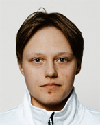

8

0.488

0.134

0.476

0.568

14

10.06

3

0.493

Megan Keller

Defense

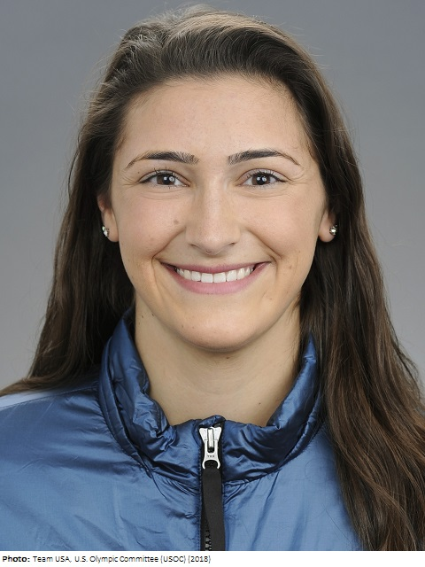

14

0.477

0.109

0.472

0.526

34

16.71

5

0.504

Minnamari Tuominen

Defense

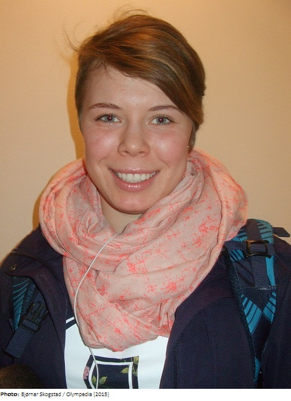

7

0.472

0.137

0.462

0.548

15

12.37

3

0.495

Abby Roque

Center

[figure not shown]

7

0.375

0.123

0.367

0.454

19

12.54

0

No Plays

Ronja Savolainen

Defense

[figure not shown]

22

0.264

0.077

0.262

0.340

43

13.76

15

0.263

<sup>1</sup> Plays include passes, takeaways, dump in/outs, zone entries,shots, puck recoveries (Avg. 8 plays per defender in overall dataset)

<sup>2</sup> DPAA uses 5 MCMC chains

<sup>3</sup> standard deviations for DPAA

<sup>4</sup> Mean simulation of Posteriors using 10,000 simulations

<sup>5</sup> Standard deviation of simulation of Posteriors using 10,000 simulations

**Canada**:  
+ *Rebecca Johnston (Center)*: -0.219  
+ *Natalie Spooner (Center)*: -0.187  
+ *Mich Zandee-Hart (Defense)*: -0.148

**Finland**  
+ *Susanna Tapani (Center)*: -0.227  
+ *Sini Karjalainen (Defense)*: -0.199  
+ *Ella Viitasuo (Defense)*: -0.040

**ROC**  
+ *Fanuza Kadirova (Left Wing)*: -0.088  
+ *Maria Batalova (Center)*: 0.014  
+ *Angelina Goncharenko (Defense)*: 0.017

**Switzerland**  
+ *Lara Christen (Defense)*: -0.226  
+ *Nicole Vallario (Defense)*: -0.225  
+ *Alina Marti (Center)*: -0.218

**USA**  
+ *Alex Carpenter (Left Wing)*: -0.143  
+ *Lee Stecklein (Defense)*: -0.060  
+ *Dani Cameranesi (Center)*: 0.003

*Not listing passing plays below, given a majority/all were passing plays*

Bottom Defending Plays Above Average

Data: Stathletes | Int'l Games: 2022 Winter Olympics | Min. 6 Plays defended; DPAA < 0

Player

Pos.

Passes<sup>1</sup>

DPAA<sup>2</sup>

DPAA Sdev<sup>3</sup>

DPAA (Sim Posteriors)<sup>4</sup>

DPAA Sdev (Sim Posteriors)

Off. Players Guarding

Avg. Separation to Closest Player (m)

Susanna Tapani

Center

[figure not shown]

14

-0.227

0.125

-0.222

-0.180

40

19.42

Lara Christen

Defense

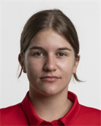

14

-0.226

0.143

-0.219

-0.154

25

14.18

Nicole Vallario

Defense

[figure not shown]

8

-0.225

0.166

-0.216

-0.108

13

8.86

Rebecca Johnston

Center

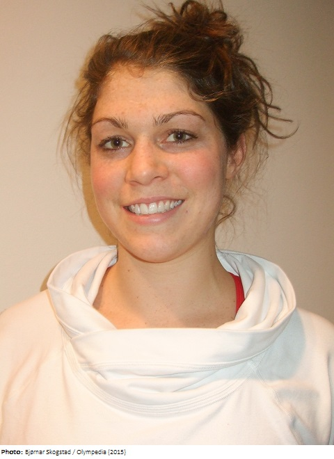

[figure not shown]

9

-0.219

0.194

-0.209

-0.132

15

15.93

Alina Marti

Center

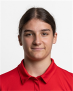

11

-0.218

0.186

-0.210

-0.145

19

19.08

<sup>1</sup> Plays include passes, takeaways, dump in/outs, zone entries,shots, puck recoveries (Avg. Player had 8 plays apart of)

<sup>2</sup> DPAA uses 5 MCMC chains

<sup>3</sup> standard deviations for DPAA

<sup>4</sup> Simulation of Posteriors using 10,000 simulations

In examining the top players positioning for defending plays: One common thread amongst these players is there ability to guard the blue line, which may be more indicative of the team strategy or individual performance

[figure not shown]

Game Notes: USA outshot Canada 53-27, although Brianne Jenner scored on the power play, USA held scoreless on their first power play. Canada also scored on a power play. USA had a 6-4 advantage but remained unable to score. In essense, US weren’t able to capitalize on power play and Canada’s below average defense (credit to great goaltending)k

References:

https://www.baseballprospectus.com/leaderboards/catching/

https://www.baseballprospectus.com/news/article/38289/bayesian-bagging-generate-uncertainty-intervals-catcher-framing-story/

http://mjskay.github.io/tidybayes/articles/tidy-rstanarm.html

https://www.iihf.com/en/events/2022/olympic-w/schedule

https://github.com/mtthwastn/statswithmatt/blob/master/hockey-with-r/gg-rink.R

https://hockey-graphs.com/2020/04/16/using-data-to-inform-shorthanded-neutral-zone-decisions/#more-24218